# GroupLab2.R

ianadams

2025-06-20

# Start of student assignment

## Instructions: Work in groups of 2-4 members. Each group submits a report (including R scripts and output in the format of html or pdf files) to Canvas.

### Angela Littlefield, Laura Santos-Medina, Hayley Wondra, Ian Adams

### 2. Read one of your datasets into R and complete the following tasks:

### - a. Identify a continuous variable in your dataset, provide summary statistics and graphs to describe the variable, and comment on the variable distribution

```r
                        library(ggplot2);
                        library(ggpubr)
                        data(ToothGrowth)
                        head(ToothGrowth)
```

```
                        ##    len supp dose
                        ## 1  4.2   VC  0.5
                        ## 2 11.5   VC  0.5
                        ## 3  7.3   VC  0.5
                        ## 4  5.8   VC  0.5
                        ## 5  6.4   VC  0.5
                        ## 6 10.0   VC  0.5
```

```r
                        tail(ToothGrowth)
```

```
                        ##     len supp dose
                        ## 55 24.8   OJ    2
                        ## 56 30.9   OJ    2
                        ## 57 26.4   OJ    2
                        ## 58 27.3   OJ    2
                        ## 59 29.4   OJ    2
                        ## 60 23.0   OJ    2
```

```r
                        summary(ToothGrowth$len)
```

```
                        ##    Min. 1st Qu.  Median    Mean 3rd Qu.    Max.
                        ##    4.20   13.07   19.25   18.81   25.27   33.90
```

```r
                        summary(ToothGrowth$supp)
```

```
                        ## OJ VC
                        ## 30 30
```

```r
                        summary(ToothGrowth$dose)
```

```
                        ##    Min. 1st Qu.  Median    Mean 3rd Qu.    Max.
                        ##   0.500   0.500   1.000   1.167   2.000   2.000
```

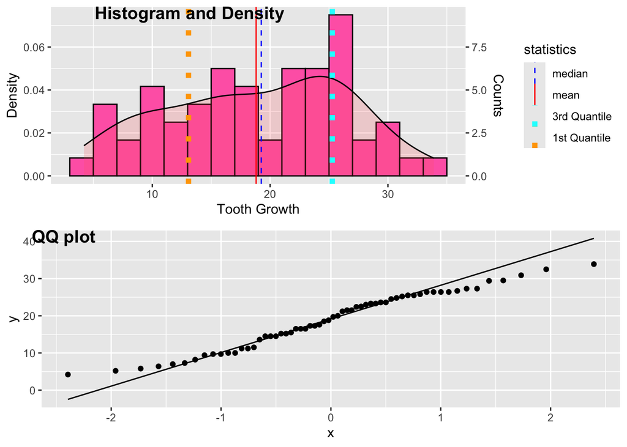

```r
                        len_hist <- ggplot(ToothGrowth, aes(x = len)) +
                            labs(x = "Tooth Growth") +
                            geom_histogram(aes(y = after_stat(density)), colour = "black", fill = "hotpink", binwidth = 2) + # the histogram is plotted initially as density, then a re-scaled y-axis shows what the count is
                            geom_density(alpha = .2, fill = "#FF6666") +
                            scale_y_continuous(name = "Density", sec.axis = sec_axis(transform = ~ . * 125, name = "Counts")) +
                            geom_vline(aes(xintercept = median(len), color = "median"), linetype = 2) +
                            geom_vline(aes(xintercept = mean(len), color = "mean"), linetype = 1) +
                            geom_vline(aes(xintercept = quantile(len, prob = 0.25), color = "1st Quantile"), linetype = 3, linewidth = 2) +
                            geom_vline(aes(xintercept = quantile(len, prob = 0.75), color = "3rd Quantile"), linetype = 3, linewidth = 2) +
                            scale_color_manual(name = "statistics", values = c("1st Quantile" = "orange", "3rd Quantile" = "cyan", median = "blue", mean = "red"), guide = guide_legend(reverse = TRUE))

                        len_qq <- ggplot(ToothGrowth, aes(sample = len)) +
                            stat_qq() +
                            stat_qq_line()

                        ggarrange(len_hist, len_qq, labels = c("Histogram and Density", "QQ plot"), ncol = 1, nrow = 2)
```

```r
                        print("The distribution of length of tooth growth is approximately normal")
```

```
                        ## [1] "The distribution of length of tooth growth is approximately normal"
```

### - b. Recode the selected variable into a new categorical variable based on biologically or clinically meaningful definitions, provide summary statistics and graphical summary of the new categorical variable

```r
                        ToothGrowth$dosecat <- recode(ToothGrowth$dose, "0:0.5='Low'; 0.51:1 = 'Med'; 1.1:2.0 = 'High'")
                        ToothGrowth$dosecat <- factor(ToothGrowth$dosecat, levels = c("Low", "Med", "High"), ordered = TRUE)
                        summary(ToothGrowth$dosecat)
```

```
                        ##  Low  Med High
                        ##   20   20   20
```

```r
                        sort(ToothGrowth$dosecat, levels = c("Low", "Med", "High"));
```

```
                        ##  [1] Low  Low  Low  Low  Low  Low  Low  Low  Low  Low  Low  Low  Low  Low  Low
                        ## [16] Low  Low  Low  Low  Low  Med  Med  Med  Med  Med  Med  Med  Med  Med  Med
                        ## [31] Med  Med  Med  Med  Med  Med  Med  Med  Med  Med  High High High High High
                        ## [46] High High High High High High High High High High High High High High High
                        ## Levels: Low < Med < High
```

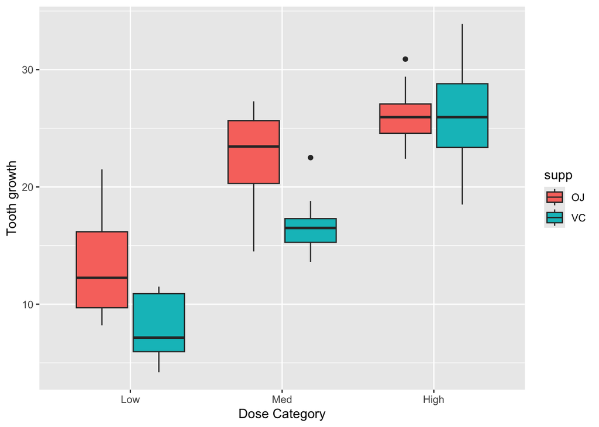

```r
                        ggplot(ToothGrowth, aes(x = dosecat, y = len, fill = supp)) +
                            geom_boxplot() +
                            xlab("Dose Category") +
                            ylab("Tooth growth")
```

### 3. Download the “Survival.csv” data set from Canvas and read the dataset into R (try to use different internet browser if there are issues downloading the data file). This data set appeared in Haberman (1976) and was obtained from the UCI Machine Learning Repository. The dataset contains cases from a study that was conducted between 1958 and 1970 at the University of Chicago’s Billings Hospital on the survival of patients who had undergone surgery for breast cancer. The variables are:

### - Age: Age of patient at the time of operation.

### - Nodes: Number of positive axillary nodes detected.

### - Status: Survival status. 1 = the patient survived 5 years or longer; 2 = the patient died within 5 year.

```r
                        dataset <- read.csv("survival.csv")
                        head(dataset)
```

```
                        ##   Age Nodes Status
                        ## 1  30     1      1
                        ## 2  30     3      1
                        ## 3  30     0      1
                        ## 4  31     2      1
                        ## 5  31     4      1
                        ## 6  33    10      1
```